# Project Foundations for Data Science: FoodHub Data Analysis

**Marks: 60**

### Context

The number of restaurants in New York is increasing day by day. Lots of students and busy professionals rely on those restaurants due to their hectic lifestyles. Online food delivery service is a great option for them. It provides them with good food from their favorite restaurants. A food aggregator company FoodHub offers access to multiple restaurants through a single smartphone app.

The app allows the restaurants to receive a direct online order from a customer. The app assigns a delivery person from the company to pick up the order after it is confirmed by the restaurant. The delivery person then uses the map to reach the restaurant and waits for the food package. Once the food package is handed over to the delivery person, he/she confirms the pick-up in the app and travels to the customer's location to deliver the food. The delivery person confirms the drop-off in the app after delivering the food package to the customer. The customer can rate the order in the app. The food aggregator earns money by collecting a fixed margin of the delivery order from the restaurants.

### Objective

The food aggregator company has stored the data of the different orders made by the registered customers in their online portal. They want to analyze the data to get a fair idea about the demand of different restaurants which will help them in enhancing their customer experience. Suppose you are hired as a Data Scientist in this company and the Data Science team has shared some of the key questions that need to be answered. Perform the data analysis to find answers to these questions that will help the company to improve the business.

### Data Description

The data contains the different data related to a food order. The detailed data dictionary is given below.

### Data Dictionary

- order_id: Unique ID of the order
- customer_id: ID of the customer who ordered the food
- restaurant_name: Name of the restaurant
- cuisine_type: Cuisine ordered by the customer
- cost: Cost of the order
- day_of_the_week: Indicates whether the order is placed on a weekday or weekend (The weekday is from Monday to Friday and the weekend is Saturday and Sunday)
- rating: Rating given by the customer out of 5
- food_preparation_time: Time (in minutes) taken by the restaurant to prepare the food. This is calculated by taking the difference between the timestamps of the restaurant's order confirmation and the delivery person's pick-up confirmation.
- delivery_time: Time (in minutes) taken by the delivery person to deliver the food package. This is calculated by taking the difference between the timestamps of the delivery person's pick-up confirmation and drop-off information

### Let us start by importing the required libraries

```python
# import libraries for data manipulation
import numpy as np
import pandas as pd

# import libraries for data visualization
import matplotlib.pyplot as plt
import seaborn as sns

# for warnings I keep getting that seem unrelated to my code
import warnings

warnings.simplefilter(action='ignore', category=FutureWarning)
```

### Understanding the structure of the data

```python
# read the data
df = pd.read_csv('foodhub_order.csv')
# returns the first 5 rows
df.head()
```

|  | order_id | customer_id | restaurant_name | cuisine_type | cost_of_the_order | day_of_the_week | rating | food_preparation_time | delivery_time |
| --- | --- | --- | --- | --- | --- | --- | --- | --- | --- |
| 0 | 1477147 | 337525 | Hangawi | Korean | 30.75 | Weekend | Not given | 25 | 20 |
| 1 | 1477685 | 358141 | Blue Ribbon Sushi Izakaya | Japanese | 12.08 | Weekend | Not given | 25 | 23 |
| 2 | 1477070 | 66393 | Cafe Habana | Mexican | 12.23 | Weekday | 5 | 23 | 28 |
| 3 | 1477334 | 106968 | Blue Ribbon Fried Chicken | American | 29.20 | Weekend | 3 | 25 | 15 |
| 4 | 1478249 | 76942 | Dirty Bird to Go | American | 11.59 | Weekday | 4 | 25 | 24 |

#### Observations:

The DataFrame has 9 columns as mentioned in the Data Dictionary. Data in each row corresponds to the order placed by a customer.

### **Question 1:** How many rows and columns are present in the data? [0.5 mark]

```python
# As stated in the head function, there are 9 columns. So let's find the rows:
rows = df.shape[0]
print(f'The dataset contains {rows} rows and 9 columns.\n')
```

```
The dataset contains 1898 rows and 9 columns.
```

#### Observations:

This set has a lot of samples.

### **Question 2:** What are the datatypes of the different columns in the dataset? (The info() function can be used) [0.5 mark]

```python
# Use info() to print a concise summary of the DataFrame

df.info()
print('\nSo the data has 1 float, 4 integers, and 4 objects.')
```

```
<class 'pandas.core.frame.DataFrame'>
RangeIndex: 1898 entries, 0 to 1897
Data columns (total 9 columns):
 #   Column                 Non-Null Count  Dtype
---  ------                 --------------  -----
 0   order_id               1898 non-null   int64
 1   customer_id            1898 non-null   int64
 2   restaurant_name        1898 non-null   object
 3   cuisine_type           1898 non-null   object
 4   cost_of_the_order      1898 non-null   float64
 5   day_of_the_week        1898 non-null   object
 6   rating                 1898 non-null   object
 7   food_preparation_time  1898 non-null   int64
 8   delivery_time          1898 non-null   int64
dtypes: float64(1), int64(4), object(4)
memory usage: 133.6+ KB

So the data has 1 float, 4 integers, and 4 objects.
```

#### Observations:

I have none; these data types make sense.

### **Question 3:** Are there any missing values in the data? If yes, treat them using an appropriate method. [1 mark]

```python
# So, the .info code says there are no non-null values. However, I went through the code myself and saw null values were listed as Not given.
# So let's check for that:

# Count the occurrences of "Not given" in each column
not_given_count = (df == "Not given").sum()

# Print the count of "Not given" values in each column
print("\nCount of 'Not given' values in each column:\n")
print(not_given_count)

# So when I first did this, the data wasn't erased because I hadn't written the next code. I have no idea if it'll appear on a fresh csv, but these were my observations:

# That makes more sense. Well, they're only in the rating section for some reason (I skimmed the code and found this to be true,
# but I didn't look at everything), but that means there are 736 null values. Now to treat them:
print("\nMissing data after treatment:\n")
# I'm doing what I would do if I had to treat the entire file, not just the ratings: replace float with mean, ints with mode, and leave objects as-is
for column in df.columns:
    # Check if the column has "Not given" values
    if "Not given" in df[column].values:
        if df[column].dtype == 'float64':  # Float columns
            # Replace "Not given" with the mean of the column
            mean_value = df[column].replace("Not given", pd.NA).astype(float).mean()
            df[column].replace("Not given", mean_value, inplace=True)
        elif df[column].dtype == 'int64':  # Integer columns
            # Replace "Not given" with the mode of the column
            mode_value = df[column].replace("Not given", pd.NA).astype(float).mode()[0]
            df[column].replace("Not given", mode_value, inplace=True)
        elif df[column].dtype == 'object':  # Object columns
            # Keep "Not given" as is for object columns
            df[column].replace("Not given", "Not Given", inplace=True)
print(not_given_count)
```

[output not shown]

#### Observations:

I'm very surprised, given how much data there is, that only the ratings had any null values. I suppose the app can track and report everything else. This also means almost 40% of these people didn't leave a rating. That's very high! I would want to see that changed, if I were working for this company.

### **Question 4:** Check the statistical summary of the data. What is the minimum, average, and maximum time it takes for food to be prepared once an order is placed? [2 marks]

```python
# Check the statistical summary of the dataset
s_summary = df.describe()
print("Statistical Summary of the Dataset:\n")
print(s_summary)

# Extract the statistics for 'food_preparation_time'
min_time = df['food_preparation_time'].min()
avg_time = round(df['food_preparation_time'].mean(), 3) # Rounding because the full number was really long
max_time = df['food_preparation_time'].max()

# Print the specific statistics for food preparation time
print("\nFood Preparation Time Statistics:")
print(f"Minimum time: {min_time} minutes")
print(f"Average (mean) time: {avg_time} minutes")
print(f"Maximum time: {max_time} minutes")
```

```
Statistical Summary of the Dataset:

           order_id    customer_id  cost_of_the_order  food_preparation_time  \
count  1.898000e+03    1898.000000        1898.000000            1898.000000
mean   1.477496e+06  171168.478398          16.498851              27.371970
std    5.480497e+02  113698.139743           7.483812               4.632481
min    1.476547e+06    1311.000000           4.470000              20.000000
25%    1.477021e+06   77787.750000          12.080000              23.000000
50%    1.477496e+06  128600.000000          14.140000              27.000000
75%    1.477970e+06  270525.000000          22.297500              31.000000
max    1.478444e+06  405334.000000          35.410000              35.000000

       delivery_time
count    1898.000000
mean       24.161749
std         4.972637
min        15.000000
25%        20.000000
50%        25.000000
75%        28.000000
max        33.000000

Food Preparation Time Statistics:
Minimum time: 20 minutes
Average (mean) time: 27.372 minutes
Maximum time: 35 minutes
```

#### Observations:

This has more to do with Python, but I wonder why the order ID is in scientific notation when it would be much more efficient to put just the number. But besides that, it seems there doesn't seem to be really any outliers for delivery or food prep time. That's very impressive--this app seems to be efficient. The cost of the orders are very much on the cheap side, though. There was a 4 dollar order? and the max was only 35? I would address that, as well, if I worked for the company.

### **Question 5:** How many orders are not rated? [1 mark]

```python
# Well I addressed that above, but I can do it again:

print("Count of 'Not given' values in each column:\n")
print(not_given_count)
print('\nThere are 736 unrated orders.')

# Again, I treated the ratings with the formula for Question 3 after writing this code. There *were* 736 unrated orders.
```

```
Count of 'Not given' values in each column:

order_id                   0
customer_id                0
restaurant_name            0
cuisine_type               0
cost_of_the_order          0
day_of_the_week            0
rating                   736
food_preparation_time      0
delivery_time              0
dtype: int64

There are 736 unrated orders.
```

#### Observations:

Again, that seems high.

### Exploratory Data Analysis (EDA)

### **Question 6:** Explore all the variables and provide observations on their distributions. (Generally, histograms, boxplots, countplots, etc. are used for univariate exploration.) [9 marks]

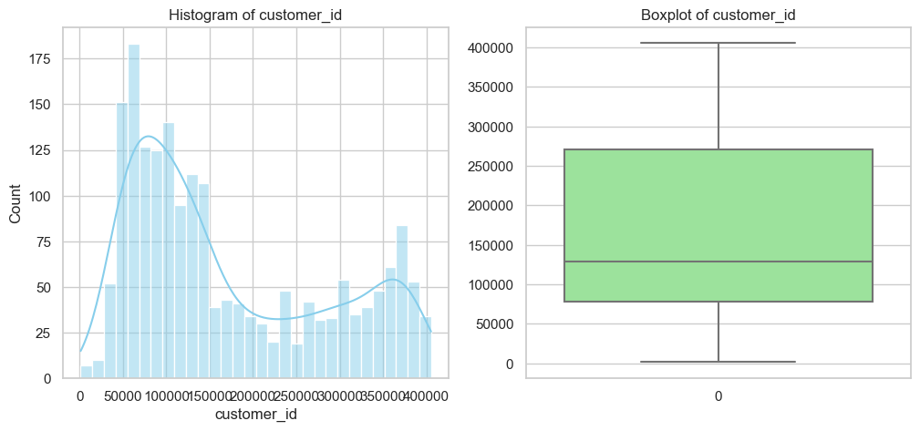

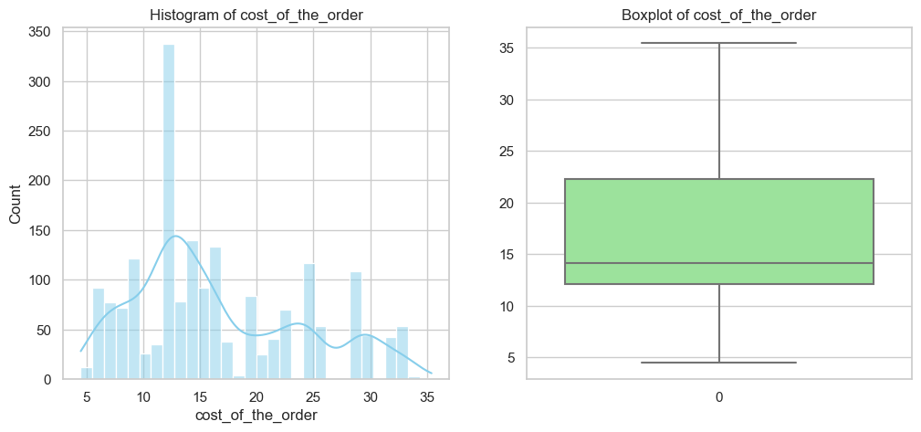

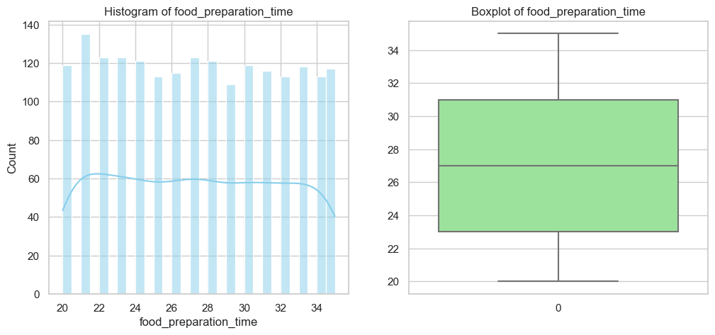

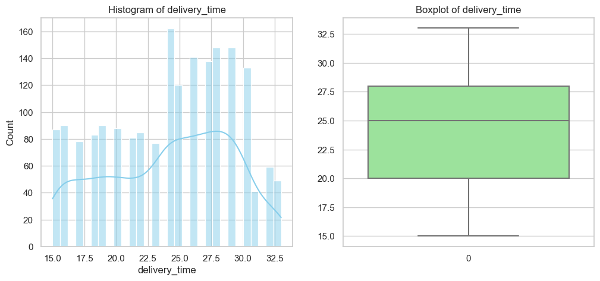

```
The restaurant with the unreadable character appears 6 times in the dataset.
```

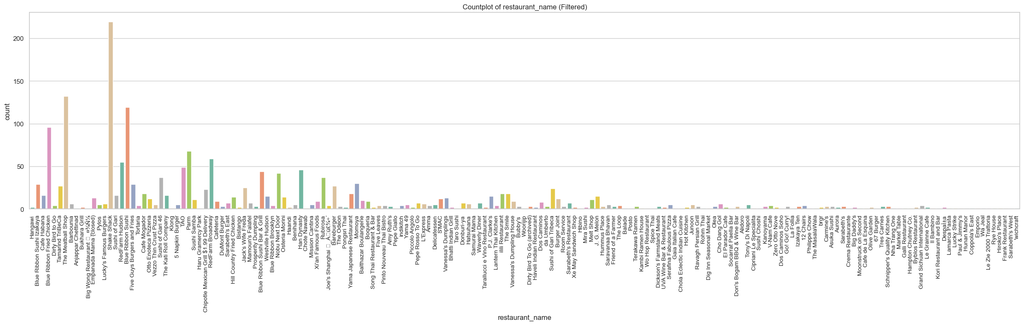

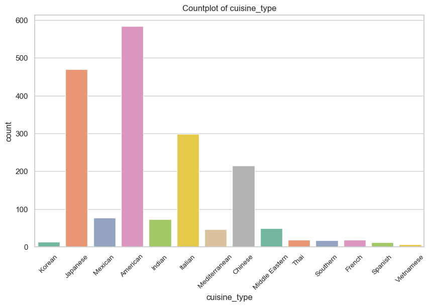

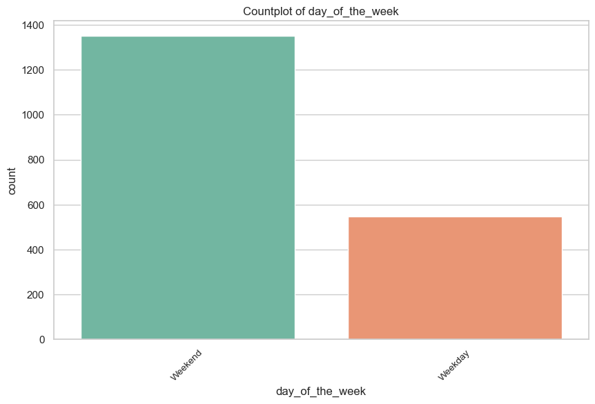

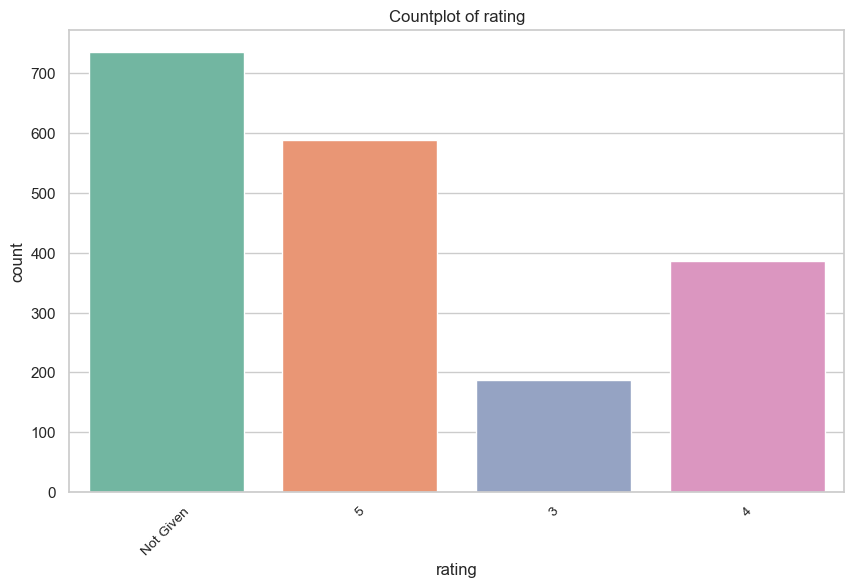

```python
# Set a font that supports more characters
plt.rcParams['font.family'] = 'DejaVu Sans'
# I thought I needed to do this because I kept getting a glyph warning for the restaurant name, and a broken graph. It didn't work, and I went through
# the code manually and saw a strange name for one of the restaurants. I don't think I should remove it, it's data for a whole restaurant, and I'm
# already trying to make a readable restaurant names countplot as-is, so I'll leave it for now.

# Edit: in the end, the only way I could print a semi-legible and functioning countplot for the restaurant names is after I removed the restaurant
# with the offending character (I only chose to check for the copyright symbol, since the symbol's value was easy to find). Also, there appear to be
# other unreadable names, however I don't know what their original name is supposed to be, but I'm not going to remove them because only the one
# with the copyright symbol seems to have broken the graph because it works now. I counted the instances of the name in the code, and it's only 6.

# Set the aesthetic style for the plots
sns.set(style="whitegrid")

# Remove 'order_id' from the numerical columns list. Unless I'm misunderstanding it, it doesn't seem important here.
numerical_columns = df.select_dtypes(include=['int64', 'float64']).columns
numerical_columns = numerical_columns.drop(['order_id'])  # Drop the order id column.

# Plot histograms and boxplots for each remaining numerical column
for column in numerical_columns:
    plt.figure(figsize=(12, 5))

    # Histogram
    plt.subplot(1, 2, 1)
    sns.histplot(df[column], bins=30, kde=True, color='skyblue')
    plt.title(f'Histogram of {column}')

    # Boxplot
    plt.subplot(1, 2, 2)
    sns.boxplot(df[column], color='lightgreen')
    plt.title(f'Boxplot of {column}')

    plt.show()

# Univariate Analysis: Categorical Columns (Countplots)
# Identify the restaurant with the unreadable character (in this case, contains a copyright symbol)
unreadable_restaurant = df[df['restaurant_name'].str.contains('\u00A9', na=False)]['restaurant_name'].unique()
# Count the instances it appears
restaurant_with_unreadable_char_count = df['restaurant_name'].str.contains('\u00A9', na=False).sum()

# Print the count
print(f"The restaurant with the unreadable character appears {restaurant_with_unreadable_char_count} times in the dataset.")

# Filter out the restaurant(s) with unreadable characters
df_filtered = df[~df['restaurant_name'].str.contains('\u00A9', na=False)]

# Univariate Analysis: Categorical Columns (Countplots)
categorical_columns = df.select_dtypes(include=['object']).columns

# Plot countplots for each categorical column
for column in categorical_columns:
    if column == 'restaurant_name':
        # Adjust the figure size for restaurant_name to be wider
        plt.figure(figsize=(30, 6))  # Stretch the width to 30 for better readability

        # Create countplot for restaurant_name (filtered)
        sns.countplot(data=df_filtered, x=column, palette='Set2')

        # Rotate labels and use a smaller font size for restaurant names
        plt.title(f'Countplot of {column} (Filtered)')
        plt.xticks(rotation=90, fontsize=10)  # Rotate for restaurant names

    else:
        plt.figure(figsize=(10, 6))

        # Create countplot for other categorical columns
        sns.countplot(data=df, x=column, palette='Set2')

        # Use default rotation and font size for other categories
        plt.title(f'Countplot of {column}')
        plt.xticks(rotation=45, fontsize=10)

    # Show the plot
    plt.show()
```

### **Question 7**: Which are the top 5 restaurants in terms of the number of orders received? [1 mark]

```python
# Find the 5 most frequent restaurant names (most to least popular)
top_5_restaurants = df['restaurant_name'].value_counts().head(5)

# Print the result
print(top_5_restaurants)
```

```
restaurant_name
Shake Shack                  219
The Meatball Shop            132
Blue Ribbon Sushi            119
Blue Ribbon Fried Chicken     96
Parm                          68
Name: count, dtype: int64
```

#### Observations:

Shake Shack is very popular. I noticed the top 3, from the graph, were much more popular than the other several dozen/hundred. It makes sense, but it's still interesting.

### **Question 8**: Which is the most popular cuisine on weekends? [1 mark]

```python
# Filter the dataset to include only weekend orders
weekend_df = df[df['day_of_the_week'].isin(['Weekend'])]

# Find the most popular cuisine on weekends
most_popular_cuisine_weekends = weekend_df['cuisine_type'].value_counts().idxmax()

# Print the result
print(f"The most popular cuisine on weekends is: {most_popular_cuisine_weekends}\n")

# Just because I'm curious
weekday_df = df[df['day_of_the_week'].isin(['Weekday'])]

# Find the most popular cuisine on weekdays
most_popular_cuisine_weekdays = weekday_df['cuisine_type'].value_counts().idxmax()

# Find the most popular cuisine overall
most_popular_cuisine_overall = df['cuisine_type'].value_counts().idxmax()

# Print the results
print(f"The most popular cuisine on weekdays is: {most_popular_cuisine_weekdays}")
print(f"The most popular cuisine overall is: {most_popular_cuisine_overall}")
```

```
The most popular cuisine on weekends is: American

The most popular cuisine on weekdays is: American
The most popular cuisine overall is: American
```

#### Observations:

Well that would've been interesting if it differed from the other results, but the most popular food in this data set is American, on weekends and weekdays.

### **Question 9**: What percentage of the orders cost more than 20 dollars? [2 marks]

```python
# Calculate the percentage of orders that cost more than 20
percentage_over_20 = (df[df['cost_of_the_order'] > 20].shape[0] / df.shape[0]) * 100

# Print the result
print(f"Percentage of orders that cost over 20 dollars: {percentage_over_20}%")
```

```
Percentage of orders that cost over 20 dollars: 29.24130663856691%
```

#### Observations:

That seems very low, I would have a talk with the business people over this data.

### **Question 10**: What is the mean order delivery time? [1 mark]

```python
# Calculate the mean delivery time
mean_delivery_time = df['delivery_time'].mean()

# Print the result
print(f"Mean order delivery time: {mean_delivery_time} minutes")
```

```
Mean order delivery time: 24.161749209694417 minutes
```

#### Observations:

24 minutes is pretty good!

### **Question 11:** The company has decided to give 20% discount vouchers to the top 3 most frequent customers. Find the IDs of these customers and the number of orders they placed. [1 mark]

```python
# Find the top 3 most frequent customers based on the number of orders placed
top_3_customers = df['customer_id'].value_counts().head(3)

# Print the result
print("Top 3 most frequent customers and the number of orders they placed:")
print(top_3_customers)
```

```
Top 3 most frequent customers and the number of orders they placed:
customer_id
52832    13
47440    10
83287     9
Name: count, dtype: int64
```

#### Observations:

No observations, these don't seem to be extraordinary.

### **Question 12**: Perform a multivariate analysis to explore relationships between the important variables in the dataset. (It is a good idea to explore relations between numerical variables as well as relations between numerical and categorical variables) [10 marks]

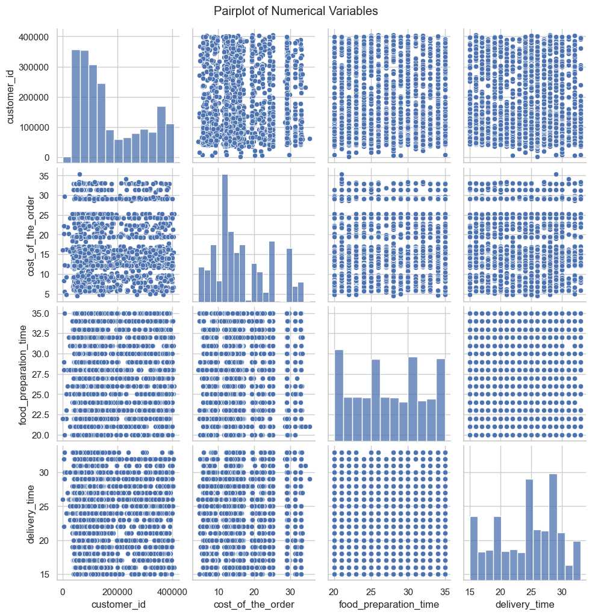

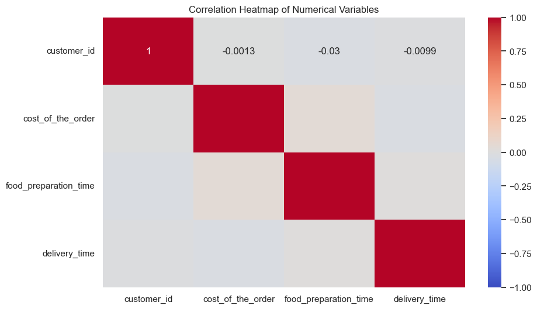

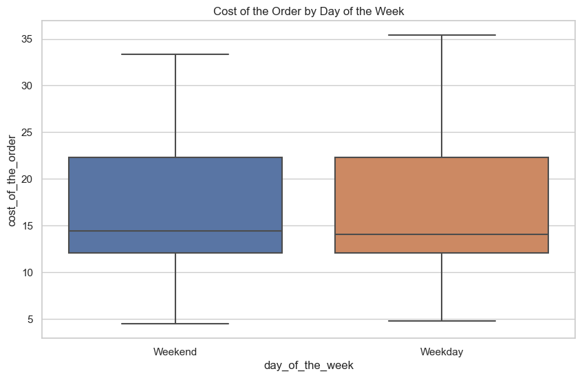

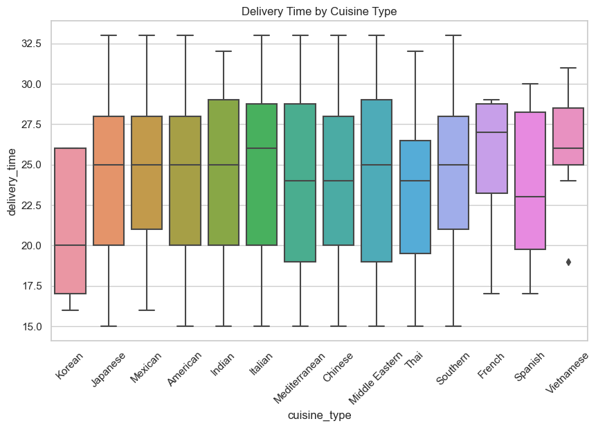

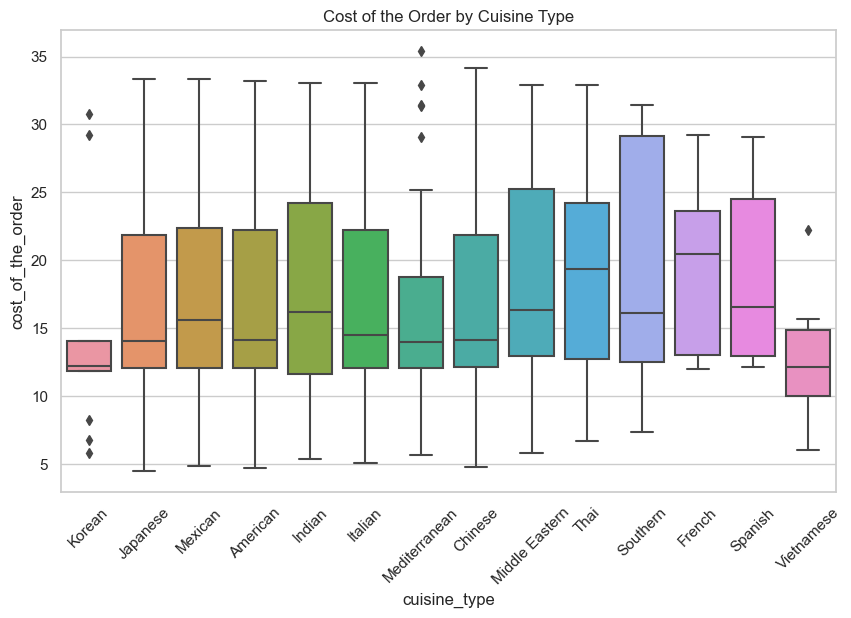

```python
# Set the aesthetic style for the plots
sns.set(style="whitegrid")

### Relationship Between Two Numerical Variables
# Use pairplot to explore relationships between numerical variables
numerical_columns = df.select_dtypes(include=['float64', 'int64']).columns

# Exclude order ID column from the pairplot, again it doesn't seem useful
numerical_columns = numerical_columns.drop(['order_id'])

# Pairplot to explore relationships between numerical variables
sns.pairplot(df[numerical_columns])
plt.suptitle('Pairplot of Numerical Variables', y=1.02)
plt.show()

### Correlation Heatmap of Numerical Variables
# Calculate the correlation matrix
correlation_matrix = df[numerical_columns].corr()

# Heatmap to visualize correlations between numerical variables
# I cannot get the heatmap to show all of the numbers despite my many attempts. It works just fine in Google Colab.
plt.figure(figsize=(10, 6))
sns.heatmap(correlation_matrix, annot=True, cmap='coolwarm', vmin=-1, vmax=1)
plt.title('Correlation Heatmap of Numerical Variables')
plt.show()

### Relationship Between Numerical and Categorical Variables
# Boxplot: Cost of the order by day of the week
plt.figure(figsize=(10, 6))
sns.boxplot(x='day_of_the_week', y='cost_of_the_order', data=df)
plt.title('Cost of the Order by Day of the Week')
plt.show()

# Boxplot: Delivery time by cuisine type
plt.figure(figsize=(10, 6))
sns.boxplot(x='cuisine_type', y='delivery_time', data=df)
plt.title('Delivery Time by Cuisine Type')
plt.xticks(rotation=45)
plt.show()

# Boxplot: Cost of the order by cuisine type
plt.figure(figsize=(10, 6))
sns.boxplot(x='cuisine_type', y='cost_of_the_order', data=df)
plt.title('Cost of the Order by Cuisine Type')
plt.xticks(rotation=45)
plt.show()
```

### **Question 13:** The company wants to provide a promotional offer in the advertisement of the restaurants. The condition to get the offer is that the restaurants must have a rating count of more than 50 and the average rating should be greater than 4. Find the restaurants fulfilling the criteria to get the promotional offer. [3 marks]

```python
# The first issue to address is the Not Given ratings, then we can answer this question:

# Convert the 'rating' column to numeric, forcing invalid entries to NaN
df['rating'] = pd.to_numeric(df['rating'], errors='coerce')

# Drop rows where 'rating' is NaN
df = df.dropna(subset=['rating'])

# Group by 'restaurant_name' and calculate the count and average of ratings for each restaurant
restaurant_rating_stats = df.groupby('restaurant_name').agg(
    rating_count=('rating', 'count'),
    average_rating=('rating', 'mean')
).reset_index()

# Apply the conditions: count of ratings > 50 and average rating > 4
eligible_restaurants = restaurant_rating_stats[
    (restaurant_rating_stats['rating_count'] > 50) &
    (restaurant_rating_stats['average_rating'] > 4)
]

# Print the eligible restaurants
print("Restaurants eligible for the promotional offer:")
print(eligible_restaurants)
```

```
Restaurants eligible for the promotional offer:
               restaurant_name  rating_count  average_rating
16   Blue Ribbon Fried Chicken            64        4.328125
17           Blue Ribbon Sushi            73        4.219178
117                Shake Shack           133        4.278195
132          The Meatball Shop            84        4.511905
```

#### Observations:

There is an issue with this, which is so few companies even have 50 ratings. And, unfortunately, nearly 40% of all ratings are missing, which makes this issue way more apparent.

### **Question 14:** The company charges the restaurant 25% on the orders having cost greater than 20 dollars and 15% on the orders having cost greater than 5 dollars. Find the net revenue generated by the company across all orders. [3 marks]

```python
# Initialize the 'revenue' column to 0.0 using .loc[] to avoid the warning I got several times in trying to make this code
df.loc[:, 'revenue'] = 0.0

# Apply a 25% charge for orders with a cost greater than 20 dollars
df.loc[df['cost_of_the_order'] > 20, 'revenue'] = df['cost_of_the_order'] * 0.25

# Apply a 15% charge for orders with a cost greater than 5 dollars and less than or equal to 20 dollars
df.loc[(df['cost_of_the_order'] > 5) & (df['cost_of_the_order'] <= 20), 'revenue'] = df['cost_of_the_order'] * 0.15

# Calculate the total revenue by summing the revenue column
total_revenue = df['revenue'].sum()

# Print the result
print(f"Total net revenue generated by the company: ${total_revenue:.2f}")
```

```
Total net revenue generated by the company: $3865.57
```

### **Question 15:** The company wants to analyze the total time required to deliver the food. What percentage of orders take more than 60 minutes to get delivered from the time the order is placed? (The food has to be prepared and then delivered.) [2 marks]

```python
# Calculate the total time using .loc[] to avoid SettingWithCopyWarning that keeps coming up from my code
df.loc[:, 'total_time'] = df['food_preparation_time'] + df['delivery_time']

# Count the number of orders where total time is greater than 60 minutes
orders_over_60 = df[df['total_time'] > 60].shape[0]

# Calculate the percentage of orders that take more than 60 minutes
total_orders = df.shape[0]
percentage_over_60 = (orders_over_60 / total_orders) * 100

# Print the result
print(f"Percentage of orders taking more than 60 minutes: {percentage_over_60}%")
```

```
Percentage of orders taking more than 60 minutes: 10.240963855421686%
```

#### Observations:

That seems normal. 10% of orders take over 60 minutes including food prep and delivery? Not bad.

### **Question 16:** The company wants to analyze the delivery time of the orders on weekdays and weekends. How does the mean delivery time vary during weekdays and weekends? [2 marks]

```python
# Separate the dataset into weekdays and weekends
weekday_df = df[df['day_of_the_week'].isin(['Weekday'])]
weekend_df = df[df['day_of_the_week'].isin(['Weekend'])]

# Calculate the mean delivery time for weekdays and weekends
mean_delivery_time_weekdays = weekday_df['delivery_time'].mean()
mean_delivery_time_weekends = weekend_df['delivery_time'].mean()

# Print the results
print(f"Mean delivery time on weekdays: {mean_delivery_time_weekdays} minutes")
print(f"Mean delivery time on weekends: {mean_delivery_time_weekends} minutes")
```

```
Mean delivery time on weekdays: 28.305882352941175 minutes
Mean delivery time on weekends: 22.436739659367397 minutes
```

#### Observations:

I'm a bit surprised it takes longer on weekdays. I would've expected it to be reversed. Maybe more drivers available on the weekend? I'm not sure.

### Conclusion and Recommendations

### **Question 17:** What are your conclusions from the analysis? What recommendations would you like to share to help improve the business? (You can use cuisine type and feedback ratings to drive your business recommendations.) [6 marks]

### Conclusions:

- This is working really well for restaurants like Shake Shack, which benefit from this app and don't mind the extra fees.
- There should be some different way to name certain restaurants in the file so they can be properly analyzed by data scientists.
- The delivery and food prep times seem quite efficient!

### Recommendations:

- I would strongly suggest some kind of incentive for rating on the part of the customers (or just force them to rate), if the company ever plans to reward businesses by their rating.
- I would also recommend reducing the amount the company charges the businesses--25% is a huge amount for small restaurants, which already have tight profit margins.
- And, despite the huge charges by the company, this app really doesn't seem to be making much money. Maybe it's new and they're still getting their feet off the ground, so it's not something I would worry about in that case. But if they're an established business, then this is a bit of a problem and I would recommend better advertising and marketing. A very large company (ie DoorDash) can easily get away with charging less from each order because they see a lot of orders.